# POLITICS OF COVID-19

Saunders

### Updated: 2020-09-28 15:19:28 PDT

#### Original version created 2020-09-21. See below for revision history

# Intro

The spread of the SARS-COV-19 viral disease varies widely between political jurisdiction. There have been several point observations, sich has [here](https://thehill.com/homenews/state-watch/515038-70-percent-of-new-coronavirus-cases-are-coming-from-red-states).

However, wider correlations between poltical speech and governance have not been drawn.

This analysis seeks to fill partially that gap. It includes:  
1. Analysis of COVID spread by poitical leadership affilation.  
2. What-if analysis based on critical turning points in disease evolution.

This computed document is constantly evolving, so please “refresh” for the latest updates. If you have suggestions or comments please reach out on twitter [@WinstonOnData](https://twitter.com/WinstonOnData) or facebook.

# National Statistics

## Total Cases and Deaths

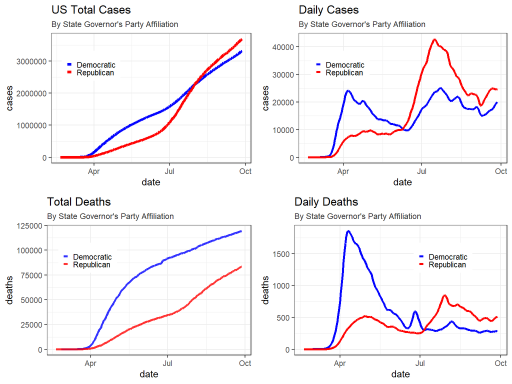

## Cases and Deaths Per 100k Population

This is similar data with the data normalized to the population. The conclusions don’t change dramatically, but do reflect the sparser population of Republican led States.

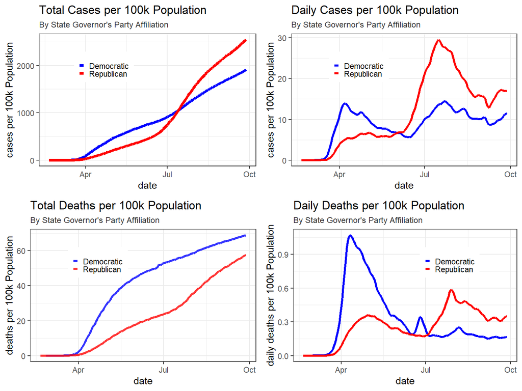

## Trend Chart of Per Capita Deaths

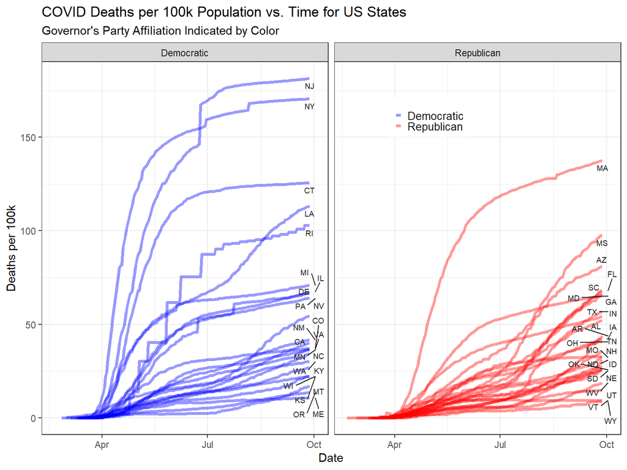

# State-Level Bar Charts

## Total Cases per 100k Population by State

This is a State-wise analysis of COVID statistics intended to highlight any correlations between political leadership and disease outcomes.

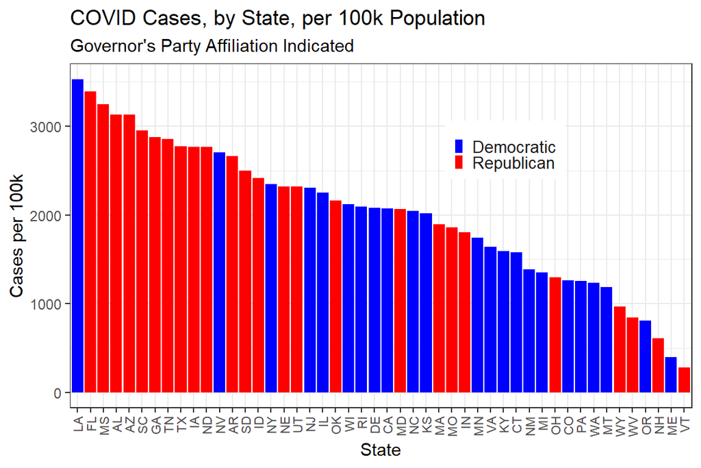

## Total Deaths by State Per 100k Population

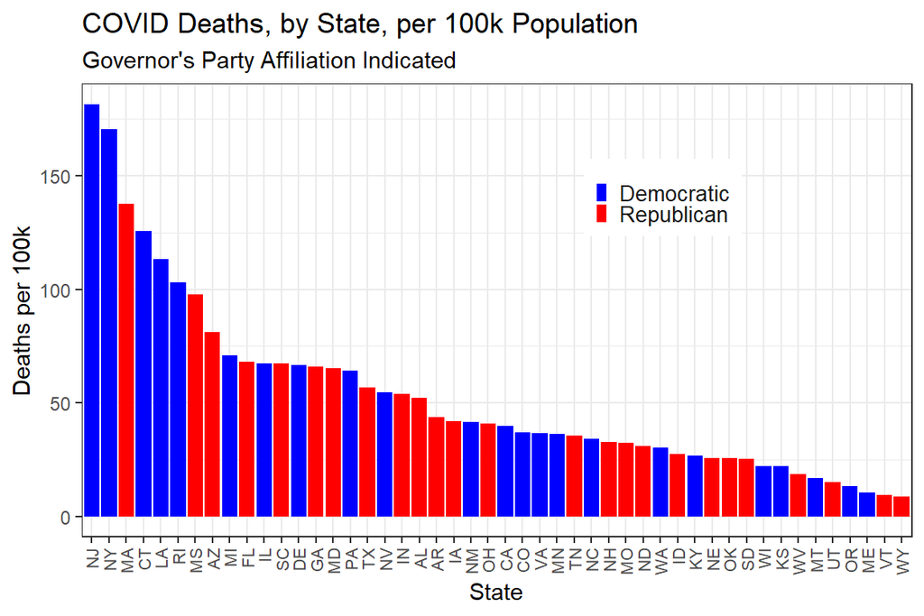

## Deaths by State *since 2020-06-01* Per 100k Population

Many State Governors relaxed staty-at-home orders as early as Mid May. Subequently, cases surged, resulting in a spike in deaths.

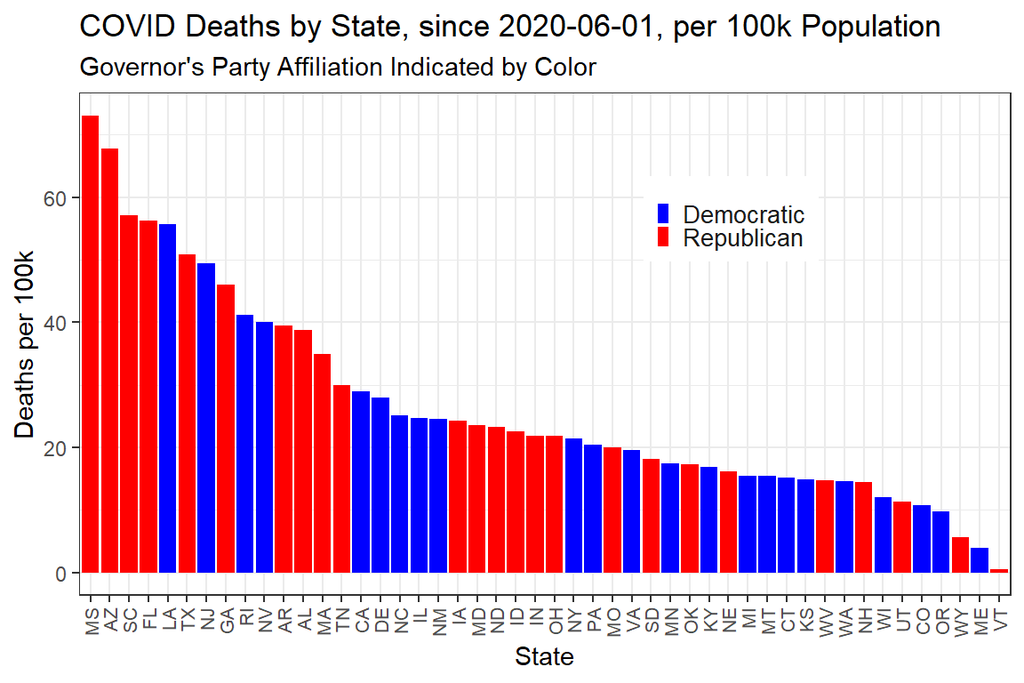

## Effective Reproduction Rate $R_e$

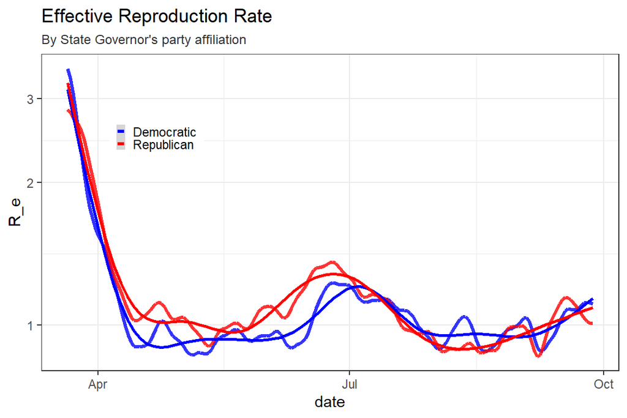

# National Maps

The key indicator for disease forcasting is the Effective Reproduction Rate $R_e$, which is a measure of how many new cases each existing case of disease creates.

When a lot of people are sick in a population without mass-immunity you want $R_e \ll 1$ or $log_2$($R_e$) < 0) to acheive negative disease growth.

After achieving negative growth, the next phase of recovery is maintaining consistently lower levels of disease to a level where disease cases can be micro-managed. There’s no clear agreement on how few that is, but I’ve seen estimates as low as 500 cases per day across the US (about 0.16 cases per 100k population).

An estimate of the disease “toll” is the number of officially tallied deaths. It is fully agreed this vastly underestimates that actual cost of the disease. Death counts are almost certainly [underestimated](https://www.wsj.com/articles/covid-19s-exact-toll-is-murky-though-u-s-deaths-are-up-sharply-11589555652) and this does not reflect any [long lasting](https://www.mayoclinic.org/diseases-conditions/coronavirus/in-depth/coronavirus-long-term-effects/art-20490351) health effects on those who recover.

## State Level Data

### Pandemic Totals

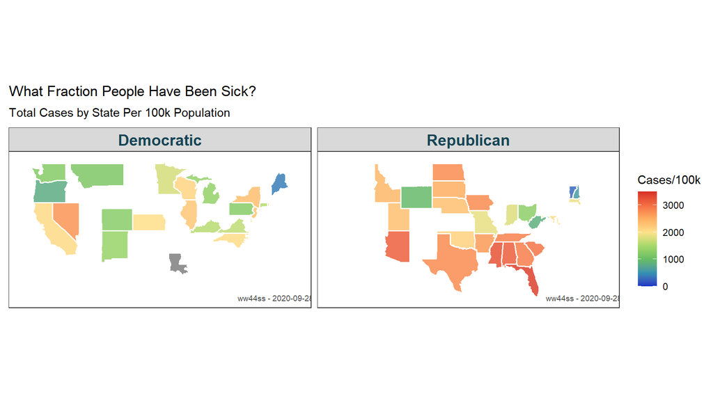

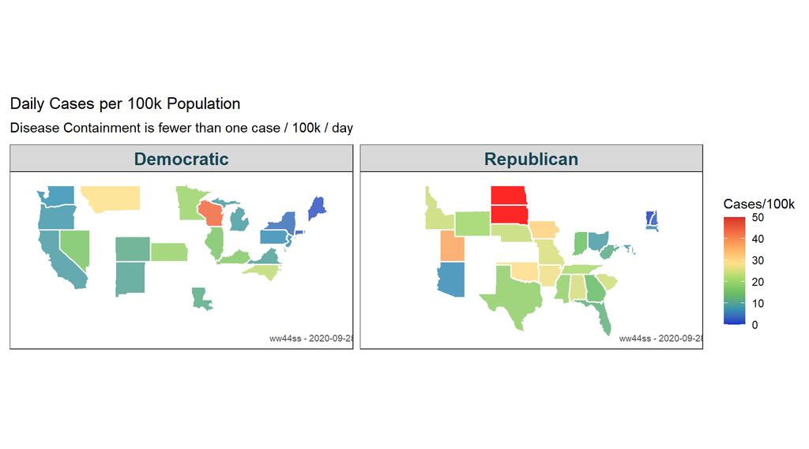

## County Level Data

While the State-Level Data Tell as remarkable story, it is also interesting to look at County-level data

### County Level Data

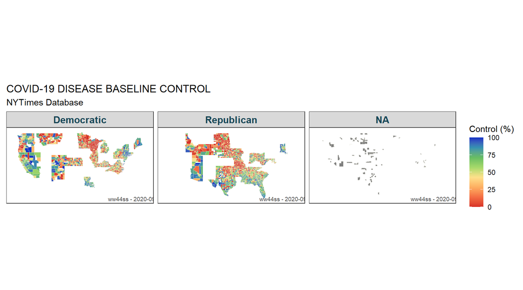

# Conclusions

It’s in control some places, but not all places. And many places are completely out-of-control.  
**Wash Your Hands!**  
**Socially Distance!**  
**…and PLEASE WEAR A MASK**

Built with R Version 4.0.2  
This document took 131.2 seconds to compute.  
2020-09-28 15:21:40

## version history

Today is 2020-09-28.  
7 days ago: Branched from Regional COVID ANALYSIS.

# Appendix: Methods

Disease data are sourced from the NYTimes [Github Repo](https://github.com/nytimes/covid-19-data). Population data are sourced from the US Census census.gov

Case growth is assumed to follow a linear-partial differential equation. This type of model is useful in populations where there is still very low immunity and high susceptibility.

$$\frac{\partial}{\partial t} cases(t, t_d) = a \times cases(t, t_d)$$
$cases(t)$ is the number of active cases at $t$ dependent on recent history, $t_d$. The constant $a$ and has units of $time^{-1}$ and is typically computed on a daily basis
Solution results are often expressed in terms of the Effective Reproduction Rate $R_e$, where
$$a \space = \space ln(R_e).$$

$R_e$ has a simple interpretation; when $R_e \space > \space 1$ the number of $cases(t)$ increases (exponentially) while when $R_e \space < \space 1$ the number of $cases(t)$ decreases.  
Practically, computing $a$ can be extremely complicated, depending on how functionally it is related to history $t_d$. And guessing functional forms can be as much art as science. To avoid that, let’s keep things simple…

Assuming a straight-forward flat time of latent infection $t_d$ = 12 days, with
$$f(t) = \int_{t - t_d}^{t}cases(t')\; dt' ,$$
$R_e$ reduces to a simple computation

$$R_e(t) = \frac{cases(t)}{\int_{t - t_d}^{t}cases(t')\; dt'} \times t_d .$$

Typical range of $t_d$ range $7 \geq t_d \geq 14$. The only other numerical treatment is, in order to reduce noise the data, I smooth case data with a [reticulated spline](https://www.urbandictionary.com/define.php?term=reticulating%20splines) to compute derivatives.

*DISCLAIMER:* Results are for entertainment purposes only. Please consult local authorities for official data and forecasts.